# Regneverksted #2

Versjon 1.2

# Tema: Husholdningens tilpasning

## Oppgave 3

1. Hva mener vi med nytte i konsumentteorien? Forklar forskjellen mellom ordinal og kardinal nytte.

   **Løsning:** **Nytte er et subjektivt mål på den glede eller tilfredsstillelse som en konsument har ved konsumet av et gode. Ordinal innebærer at nytten er rangerbar. Det numeriske tallet for nyttenivå har altså ingen verdi utover at den rangerer gode kombinasjoner. Kardinal nytte innebærer at nytten er målbar. Kun ved kardinal nytte er det mulig å sammenligne nytte mellom konsumenter.**
2. Hva mener vi med indifferenskurver? Skisser grafisk følgende 3 typer av indifferenskurver:

   **Løsning: En indifferenskurve er en grafisk presentasjon av ulike sammensetninger av goder som gir identisk nytte. Den er altså en grafisk presentasjon av nyttefunksjonen i et godediagram. Goder kan erstatte hverandre, de er substituerbare. Substitusjonsmulighetene fremkommer via formen på indifferenskurvene.**
   1. ordinære indifferenskurver.

   **Løsning:Vanlige indifferenskurver krummer mot origo, noe som avspeiler begrensede substitusjonsmuligheter. Slike indifferenskurver innebærer avtagende marginal substitusjonsbrøk. Jo mer en konsument har av et gode i utgangspunktet, desto mindre trenger han i kompensasjon av det andre godet dersom han blir fratatt en enhet av det godet han har rikelig av.**
   2. Indifferenskurver for en konsument som konsumerer to goder i et fast forhold (for eksempel en enhet saft og 2 enheter farrisvann)

   **Løsning: Goder som konsumeres i et fast forhold har rettvinklede indifferenskurver. I dette tilfellet har man ingen substitusjonsmuligheter, og det er et fast forhold mellom konsumerte mengder av de to godene. Godene er da komplementære. Vi får dermed ikke økt nytte dersom vi øker mengden av for eksempel saft, mens mengden av farrisvann er konstant. Vi må konsumere 1 enhet saft sammen med 2 enheter farrisvann.**
   3. en konsument som liker to goder like godt (for eksempel ferie i Norge og ferie i utlandet).

   **Løsning: Goder som er perfekt substituerbare, som f eks. norgesferie og ferie i utlandet, vil ha rettlinjede indifferenskurver. Å tilbringe 2 uker på ferie i Norge kan substitueres mot en 14 dagers utenlandsferie. Det er altså et konstant bytteforhold mellom de to godene.**
3. Hva mener vi med den marginale substitusjonsbrøk? Bruk de tre typene indifferenskurver fra oppgave 1b) i svaret ditt.

   **Løsning: Den marginale substitusjonsbrøk (MSB) viser hvor mye vi må gi opp av et gode for å få mer av et annet, når nytten er konstant. Den angir bytteforholdet mellom to goder. I tilfellet med krummede indifferenskurver, vil MSB avta langs en indifferenskurve. Er indifferenskurvene rettlinjede, vil MSB være konstant og lik 1 langs hele kurven. Er derimot indifferenskurvene rettvinklede, og det er fravær av substitusjonsmuligheter, da vil MSB være lik null langs den horisontale aksen.**
4. Hvilke kriterier må være oppfylt for at konsumenten skal oppnå maksimal nytte til en gitt inntekt? Forklar grundig, og illustrer svaret ditt med en figur.

   **Løsning: Bruk figur 7.12 i læreboka. Du skal forklare punkt a, b og c. Det er 2 betingelser som må være oppfylt for at en godekombinasjon skal være optimal:**

   **1. Den må ligge på budsjettlinjen.**

   **2 Den må være i tangeringspunktet mellom en indifferenskurve og den angitte budsjettlinjen. I c har vi tangering mellom den høyst oppnåelige indifferenskurven og budsjettlinjen. I tangeringspunktet er helningen på indifferenskurven (MRS) liker helningen på budsjettlinja, dvs at $\frac{u_1^{'}}{u_2^{'}}=\frac{p_1}{p_2}$. Dersom vi omformulerer tilpasningsbetingelsen får vi Gossens 1. lov: $\frac{u_1^{'}}{p_1}=\frac{u_2^{'}}{p_2}$. Konsumentens budsjett skal $p_1$ $p_2$ fordeles på kjøp av de 2 godene slik at nytten av den siste kronen er den samme, uansett hvilket gode den blir brukt på. Punktet a er ikke et optimumspunkt, fordi der er MSB>prisforholdet. Det innebærer at da vil konsumenten være villig til å ofre flere enheter av gode 2 for å få 1 enhet til av gode 1 (MSB) og fremdeles befinne seg på det samme nyttenivået, enn det han virkelig må ofre for å kjøpe en enhet til av gode 1 (prisforholdet). Da vil han øke sin nytte for det samme budsjettet ved å kjøpe mer av gode 1 og mindre av gode 2, og således bevege seg mot punkt c.**

   **Eksempel: Anta at $MSB = 4$ og $p1/p2 = 3$ i punkt a. For å få 1 enhet mer av gode 1, er han da villig til å ofre 4 enheter av gode 2. Det koster ham imidlertid kun 3 enheter av gode 2 for å kunne kjøpe 1 enhet av gode 1. Siden «markedet» tilbyr en lavere pris for gode 1 (3 enheter av gode 2) enn det han maksimalt hadde vært villig til å «betale» (4 enheter av gode 2), øker hans nytte når han bytter ut noe av gode 2 med mer av gode 1.**

   **Eksempel: Anta at $MSB = 2$ og $p1/p2 = 3$ i punkt b. For å gi slipp på 1 enhet av gode 1, må han da få 2 enheter av gode 2 for å opprettholde nyttenivået. Han kan imidlertid kjøpe hele 3 enheter av gode 2 dersom han kjøper 1 enhet mindre av gode 1. Siden «markedet» tilbyr ham en høyere pris for gode 1 (3 enheter av gode enn det han maksimalt hadde vært villig til å «betale» (2 enheter av gode 2), øker hans nytte når han bytter ut noe av gode 1 med mer av gode 2.**
5. En konsument, Olava, liker å kose seg på en av byens kafeer. Prisen på et stykke kake er 20 kroner, mens prisen for en kaffe latte er 40 kroner. Budsjettet til Olava er på 160 kroner. Formuler Olavas budsjettbetingelse og illustrer den grafisk i et godediagram. Du skal ha mengden kake langs den horisontale aksen og mengden kaffe latte langs den vertikale. Forklar hva budsjettlinjen gir uttrykk for. Finn også et uttrykk for helningen på kurven.

   Løsning: Budsjettbetingelsen angir hvordan det samlede budsjettet (R) fordeles på utgifter til henholdsvis gode 1 $(p_1x_1)$ og gode 2 $(p_2x_2)$:
   $$\begin{equation*}
   R=p_1x_1+p_2x_2 \Rightarrow 160=20x_1+40x_2
   \end{equation*}$$
   Budsjettlinja får vi når vi løser budsjettbetingelsen med hensyn på $x_2$, slik at den passer inn i et $x_1x_2$-diagram:
   $$\begin{equation*}
   x_2=-\frac{p_1}{p_2}x_1+\frac{R}{p_2} \Rightarrow
   \end{equation*}$$
   Helningen på budsjettlinjen:
   $$\begin{equation*}
   \frac{dx_2}{dx_1}=-\frac{p_1}{p_2}
   \end{equation*}$$
   Den er negativ, fordi kjøp av en enhet mer av gode 1 (kake), krever mindre kjøp av gode 2 (latte) med uendret budsjett. Mulighetsområdet avgrenses av de to aksene og budsjettlinjen, og angir alle de kombinasjoner av kake og latte som Olava kan kjøpe innenfor budsjettet sitt. Hun kan ikke konsumere mer enn det som inntekt og priser bestemmer og avgrenser.

   **Skjæringspunktet med den horisontale aksen ($\frac{R}{p_1}=\frac{160}{20}=8$) viser at Olava kan konsumere hele 8 kakestykker dersom hun bruker hele budsjettet på dette godet, mens skjæringspunktet med den vertikale aksen ($\frac{R}{p_2}=\frac{160}{40}=4$) viser at Olava kan konsumere 4 kopper med kaffelatte dersom hun bruker hele budsjettet på dette godet.**
6. Hva skjer med budsjettlinjen dersom inntekten reduseres til 120 kroner? Bruk også en figur i forklaringen din.

8. Olava hadde egentlig tenkt å kjøpe 2 stykker kake og 3 kaffe latte for sitt budsjett. Hva blir nyttenivået i dette tilfellet? Hvilket råd vil du som samfunnsøkonom gi henne?

   **Løsning:Hun maksimerer ikke nytten når hun konsumerer denne mengden. Dette skyldes at MSB da er 3/2, dvs hun er villig til å ofre 1,5 kaffekopper for å få ett kakestykke og samtidig opprettholde nyttenivået. Derimot kan hun kjøpe ett kakestykke og betale tilsvarende en ½ kaffekopp for dette. Hun er altså villig til å ofre flere kaffekopper for ett kakestykke enn det hun faktisk behøver for å opprettholde nyttenivået når hun kjøper dette kakestykket. Da bør hun kjøpe mer kake og færre kopper med kaffe. Dette bør hun fortsette med, helt til MSB har sunket til prisforholdet, dvs ½.**
9. Anta at prisen på kake synker. Forklar kort hva vi mener med inntekt- og substitusjonseffekt i dette tilfellet. Illustrer grafisk.

   Løsning:Forklares ved å bruke en tilsvarende figur som Figur 8.8 i læreboka. Effekten av en prisreduksjon på etterspørselen etter godet, kan dekomponeres i 2 deler: Substitusjonseffekten (prisvridningseffekten): Den nyttekompenserte virkningen på etterspørselen etter kaker som følge av at kakeprisen reduseres. Besvarer følgende spørsmål; hvordan ville etterspørselen etter kaker endret seg dersom konsumenten hadde blitt fratatt en (tenkt) del av sin inntekt slik at hun hadde beholdt den samme nytten som tidligere. Substitusjonseffekten fanger opp effekten av at prisen på kake er blitt lavere sammenlignet med prisen på det andre godet, kaffe. Denne effekten virker alltid slik at prisnedgang på kaker øker kakeetterspørselen.  
   Inntektseffekten er virkningen på kakeetterspørselen som følge av at realinntekten har gått opp siden kakeprisen har gått ned. Olavas budsjett på 160 kr har fått større kjøpekraft da ett av godene er blitt billigere. Dersom kaker er et normalt gode for Olava, drar inntektseffekten i retning av økt kakekonsum, mens det motsatte er tilfellet dersom Olava betrakter kaker som et mindreverdig gode.  
   Den samlede effekten på Olavas etterspørsel etter kaker som følge av en prisnedgang, er summen av substitusjons- og inntektseffekten. Dersom Olava oppfatter kaker som et normalt gode, vil en prisreduksjon garantert resultere i økt etterspørsel etter kaker. Dersom kaker er et mindreverdig gode, drar de to effektene i hver sin retning, men da vil substitusjonseffekten være sterkere enn inntektseffekten. Fremdeles vil den samlede virkningen være en økt etterspørsel etter kaker. Dersom kaker er et sterkt mindreverdig gode, kan vi oppleve den situasjonen at en prisnedgang på kaker fører til lavere etterspørsel etter godet. I så fall betegner vi kaker som et giffengode.

Diagramark benyttet under Videooptak.

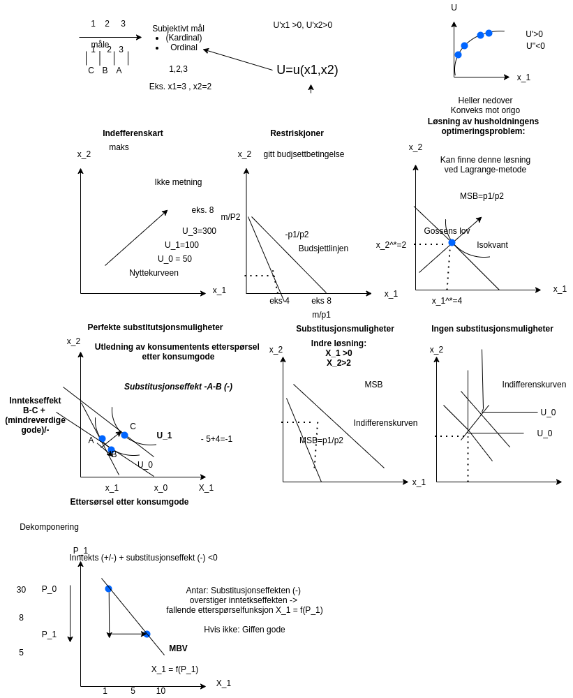